# Community Fire Safety Demographic Analysis

# DFB Community Fire Safety Demographic Analysis

## Background

This document outlines the analysis of Ireland’s 2016 Census of Population for the purpose of identifying targets for Community Fire Safety measures. It has long been thought that poverty is a key indicator of fire risk, but this analysis aims to go further and attempt to discover other factors which impact fire risk. The main source of information is the Census 2016 information at Small Area level, but other datasets will be used when deemed helpful.

## Methodology

Several methodologies will be utilised during this analysis, as listed below;

- Clustering via K-means and PAM
- Linear regression of Census Variables against Domestic Fire Incidence
- Determination of any spatial correlation of Domestic Fires and other fire incidents.

```r
knitr::opts_chunk$set(warning = FALSE, cache = FALSE, message = FALSE, error = FALSE, tidy = TRUE)
library(tidyverse)
library(magrittr)
library(lubridate)
```

```r
dublin_saps_2016 <- read_csv("data/dublin2016_SAPS.csv")
```

## Step 1 - Variable preparation

The Census Data is divided into subject areas called themes; for example Theme 1 deals with number of people at a specific age category, while Theme 4 deals with Family make-up. These themes are further divided into sub-tables, counting specific measures within the theme. Since each Small Area has slightly differing populations, in order to compare across Small Areas, it is necessary to convert the raw information into proportions. During this exercise, it would be useful to select which themes might be predictive of fire risk; for this we might take guidance from some recent studies in this area, such as the [Profile of fire fatalities in Ireland using coronial data](https://www.sciencedirect.com/science/article/pii/S0379711218305708). In this, risk factors such as;  
* Being older than 65 years of age * Being Male * Dwelling in a rural area * Alcohol and Drug consumption * Living Alone * Smoking

had high prevalence as factors in people who died from fire during the years 2014 to 2016.

The following themes and sub-tables were used:  
Themes Tables Within Themes

Theme 1: Sex, Age and Marital Status  
Population aged 0 - 19 by sex and year of age, population over 65 and the remainder as three groups. Theme 2: Migration, Ethnicity, Religion and Foreign Languages  
Usually resident population by ethnic or cultural background Usually resident population aged 1 year and over by usual residence 1 year before Census Day Speakers of foreign languages by ability to speak English Theme 6: Housing  
Private households by type of accommodation Permanent private households by year built Permanent private households by type of occupancy Permanent private households by number of rooms Theme 8: Principal Status  
Population aged 15 years and over by principal economic status Theme 10: Education  
Population aged 15 years and over by sex and highest level of education completed Theme 12: Disability, Carers and General Health  
Persons with disability by sex Population by general health and sex

### Step 1.1 Age Related Variables.

We will stratify the age groups into those less than 18, males greater than 65, females greater than 65, and the remainder.

```r
dublin_saps_2016 %>%
  mutate(prop_lte_18 = (
           T1_1AGE0T +
           T1_1AGE1T +
           T1_1AGE2T +
           T1_1AGE3T +
           T1_1AGE4T +
           T1_1AGE5T +
           T1_1AGE6T +
           T1_1AGE7T +
           T1_1AGE8T +
           T1_1AGE9T +
           T1_1AGE10T +
           T1_1AGE11T +
           T1_1AGE12T +
           T1_1AGE13T +
           T1_1AGE14T +
           T1_1AGE15T +
           T1_1AGE16T +
           T1_1AGE17T +
           T1_1AGE18T) / T1_1AGETT,
          prop_18_to_65 = (
           T1_1AGE19T +
           T1_1AGE20_24T +
           T1_1AGE25_29T +
           T1_1AGE30_34T +
           T1_1AGE35_39T +
           T1_1AGE40_44T +
           T1_1AGE45_49T +
           T1_1AGE50_54T +
           T1_1AGE55_59T +
           T1_1AGE60_64T)/ T1_1AGETT,
          prop_gt65_M = (
           T1_1AGE65_69M +
           T1_1AGE70_74M +
           T1_1AGE75_79M +
           T1_1AGE80_84M +
           T1_1AGEGE_85M) / T1_1AGETT,
          prop_gt65_F = (
           T1_1AGE65_69F +
           T1_1AGE70_74F +
           T1_1AGE75_79F +
           T1_1AGE80_84F +
           T1_1AGEGE_85F) / T1_1AGETT
         ) %>%
  select(1, starts_with('prop'))-> t0_age
```

### Step 1.2 Country of Birth, Ethnic or Cultural Background, English Language Competency

There are many ways to segment on a “background” theme, and this can be a difficult predictor to use without singling out specific groups. To this end, the intention is to look at all factors possible and to use them naively to try and determine if any patterns are discernible.

#### Nationality

T2_1IEN Ireland - Nationality T2_1UKN UK - Nationality T2_1PLN Poland - Nationality T2_1LTN Lithuania - Nationality T2_1EUN Other EU28 - Nationality T2_1RWN Rest of world - Nationality

```r
dublin_saps_2016 %>%
  mutate(
  prop_irish_nationality = T2_1IEN / T2_1TN,
  prop_uk_nationality = T2_1UKN / T2_1TN,
  prop_polish_nationality = T2_1PLN / T2_1TN,
  prop_latvian_nationality = T2_1LTN / T2_1TN,
  prop_other_eu_nationality = T2_1EUN / T2_1TN,
  prop_row_nationality = T2_1RWN / T2_1TN
  ) %>%
  select(1, starts_with("prop")) -> t0_nationality
```

#### Ethnicity

T2_2WI White Irish T2_2WIT White Irish Traveller T2_2OW Other White T2_2BBI Black or Black Irish T2_2AAI Asian or Asian Irish T2_2OTH Other

```r
dublin_saps_2016 %>%
  mutate(
  prop_white_irish = T2_2WI / T2_2T,
  prop_white_irish_traveller = T2_2WIT / T2_2T,
  prop_other_white = T2_2OW / T2_2T,
  prop_black_or_black_irish = T2_2BBI / T2_2T,
  prop_asian_asian_irish = T2_2AAI / T2_2T,
  prop_other_ethnicity = T2_2OTH / T2_2T
  ) %>%
  select(1, starts_with("prop")) -> t0_ethnicity_culture
```

#### Migration

T2_3SA Same address T2_3EC Elsewhere in county T2_3EI Elsewhere in Ireland T2_3OI Outside Ireland

```r
dublin_saps_2016 %>%
  mutate(
  prop_same_address = T2_3SA / T2_3T,
  prop_elsewhere_county = T2_3EC / T2_3T,
  prop_elsewhere_ireland = T2_3EI / T2_3T,
  prop_outside_ireland = T2_3OI / T2_3T
  ) %>%
  select(1, starts_with("prop")) -> t0_migration
```

#### English Language Competency

T2_6VW Very well T2_6W Well T2_6NW Not well T2_6NAA Not at all T2_6NS Not stated T2_6T Total

```r
dublin_saps_2016 %>%
  mutate(
  prop_english_very_well = T2_6VW / T2_6T,
  prop_english_well = T2_6W / T2_6T,
  prop_english_not_well = T2_6NW / T2_6T,
  prop_english_not_at_all = T2_6NAA / T2_6T
  ) %>%
  select(1, starts_with("prop")) -> t0_english_language
```

### Step 1.3 Housing

This theme seems to have a lot of value as it holds the best information from the Census for the built environment.

These are the available sub-tables:  
* Private households by type of accommodation * Permanent private households by year built * Permanent private households by type of occupancy * Permanent private households by number of rooms * Permanent private households by central heating * Permanent private households by water supply * Permanent private households by sewerage facility * Occupancy status of permanent dwellings on Census night

#### Type of Accommodation

T6_1_HB_H House/Bungalow (No. of households) T6_1_FA_H Flat/Apartment (No. of households) T6_1_BS_H Bed-Sit (No. of households) T6_1_CM_H Caravan/Mobile home (No. of households) T6_1_NS_H Not stated (No. of households) T6_1_TH Total (No. of households)

```r
dublin_saps_2016 %>%
  mutate(
  prop_house_bungalow = T6_1_HB_H / T6_1_TH,
  prop_flat_apartment = T6_1_FA_H / T6_1_TH,
  prop_bedsit = T6_1_BS_H / T6_1_TH,
  prop_caravan_mobile = T6_1_CM_H / T6_1_TH
  ) %>%
  select(1, starts_with("prop")) -> t0_accommodation_type
```

#### Household by Year Built

T6_2_PRE19H Pre 1919 (No. of households) T6_2_19_45H 1919 - 1945 (No. of households) T6_2_46_60H 1946 - 1960 (No. of households) T6_2_61_70H 1961 - 1970 (No. of households) T6_2_71_80H 1971 - 1980 (No. of households) T6_2_81_90H 1981 - 1990 (No. of households) T6_2_91_00H 1991 - 2000 (No. of households) T6_2_01_10H 2001 - 2010 (No. of households) T6_2_11LH 2011 or Later (No. of households) T6_2_NSH Not stated (No. of households) T6_2_TH Total (No. of households)

```r
dublin_saps_2016 %>%
  mutate(
  prop_pre1919 = T6_2_PRE19H / T6_2_TH,
  prop_1919_1945 = T6_2_19_45H / T6_2_TH,
  prop_1946_1960 = T6_2_46_60H / T6_2_TH,
  prop_1961_1970 = T6_2_61_70H / T6_2_TH,
  prop_1971_1980 = T6_2_71_80H / T6_2_TH,
  prop_1981_1990 = T6_2_81_90H / T6_2_TH,
  prop_1991_2000 = T6_2_91_00H / T6_2_TH,
  prop_2001_2010 = T6_2_01_10H / T6_2_TH,
  prop_2011_plus = T6_2_11LH / T6_2_TH
  ) %>%
  select(1, starts_with("prop")) -> t0_housing_era
```

#### Occupancy Type

T6_3_OMLH Owned with mortgage or loan (No. of households) T6_3_OOH Owned outright (No. of households) T6_3_RPLH Rented from private landlord (No. of households) T6_3_RLAH Rented from Local Authority (No. of households) T6_3_RVCHBH Rented from voluntary/co-operative housing body (No. of households) T6_3_OFRH Occupied free of rent (No. of households) T6_3_NSH Not stated (No. of households) T6_3_TH Total (No. of households)

```r
dublin_saps_2016 %>%
  mutate(
  prop_owned_mortgage = T6_3_OMLH / T6_3_TH,
  prop_owned_fully = T6_3_OOH / T6_3_TH,
  prop_rented_private = T6_3_RPLH / T6_3_TH,
  prop_rented_la = T6_3_RLAH / T6_3_TH,
  prop_rented_ahb = T6_3_RVCHBH / T6_3_TH,
  prop_rent_free = T6_3_OFRH / T6_3_TH
  ) %>%
  select(1, starts_with("prop")) -> t0_occupancy_type
```

#### Dwelling by Room Count

T6_4_1RH 1 room (No. of households) T6_4_2RH 2 rooms (No. of households) T6_4_3RH 3 rooms (No. of households) T6_4_4RH 4 rooms (No. of households) T6_4_5RH 5 rooms (No. of households) T6_4_6RH 6 rooms (No. of households) T6_4_7RH 7 rooms (No. of households) T6_4_GE8RH 8 or more rooms (No. of households) T6_4_TH Total (No. of households)

```r
dublin_saps_2016 %>%
  mutate(
  prop_one_room = T6_4_1RH / T6_4_TH,
  prop_two_rooms = T6_4_2RH / T6_4_TH,
  prop_three_rooms = T6_4_3RH / T6_4_TH,
  prop_four_rooms = T6_4_4RH / T6_4_TH,
  prop_five_rooms = T6_4_5RH / T6_4_TH,
  prop_six_rooms = T6_4_6RH / T6_4_TH,
  prop_seven_rooms = T6_4_7RH / T6_4_TH,
  prop_ge_eight_rooms = T6_4_GE8RH / T6_4_TH,
  ) %>%
  select(1, starts_with("prop")) -> t0_room_count
```

### Step 1.4 Occupation

This is a broad description of the principal occupation, not accounting for the type of work done.

T8_1_WT At work - Total T8_1_LFFJT Looking for first regular job - Total T8_1_ULGUPJT Unemployed having lost or given up previous job - Total T8_1_ST Student - Total T8_1_LAHFT Looking after home/family - Total T8_1_RT Retired - Total T8_1_UTWSDT Unable to work due to permanent sickness or disability - Total T8_1_OTHT Other - Total T8_1_TT Total

```r
dublin_saps_2016 %>%
  mutate(
  prop_at_work = T8_1_WT / T8_1_TT,
  prop_seeking_first_job = T8_1_LFFJT / T8_1_TT,
  prop_unemp = T8_1_ULGUPJT / T8_1_TT,
  prop_student = T8_1_ST / T8_1_TT,
  prop_family_care = T8_1_LAHFT / T8_1_TT,
  prop_retired = T8_1_RT / T8_1_TT,
  prop_disability_not_working = T8_1_UTWSDT / T8_1_TT
  ) %>%
  select(1, starts_with("prop")) -> t0_principle_occupation
```

### Step 1.5 Education

A simple view of the highest level of education attained is used.

T10_4_NFT No formal education - Total T10_4_PT Primary education - Total T10_4_LST Lower secondary - Total T10_4_UST Upper secondary - Total T10_4_TVT Technical or vocational qualification - Total T10_4_ACCAT Advanced certificate/Completed apprenticeship - Total T10_4_HCT Higher certificate - Total T10_4_ODNDT Ordinary bachelor degree or national diploma - Total T10_4_HDPQT Honours bachelor degree, professional qualification or both - Total T10_4_PDT Postgraduate diploma or degree - Total T10_4_DT Doctorate(Ph.D) or higher - Total T10_4_NST Not stated - Total T10_4_TT Total

```r
dublin_saps_2016 %>%
  mutate(
  prop_no_formal_education = T10_4_NFT / T10_4_TT,
  prop_primary = T10_4_PT / T10_4_TT,
  prop_lower_2ary = T10_4_LST / T10_4_TT,
  prop_upper_2ary = T10_4_UST / T10_4_TT,
  prop_technical_voc_qual = (T10_4_TVT + T10_4_ACCAT)/ T10_4_TT,
  prop_third_level = (T10_4_HCT + T10_4_ODNDT + T10_4_HDPQT + T10_4_PDT + T10_4_DT) / T10_4_TT
  ) %>%
  select(1, starts_with("prop")) -> t0_education
```

### step 1.6 Disability and General Health

#### Persons with disability by sex

T12_1_M T12_1_F T12_1_T

```r
dublin_saps_2016 %>%
  mutate(prop_w_disability = (T12_1_M + T12_1_F) / T1_1AGETT) %>%
  select(1, starts_with("prop")) -> t0_disability_status
```

Population by general health and sex

T12_3_VGT Very good - Total T12_3_GT Good - Total T12_3_FT Fair - Total T12_3_BT Bad - Total T12_3_VBT Very bad - Total T12_3_NST Not stated - Total T12_3_TT Total

```r
dublin_saps_2016 %>%
  mutate(prop_very_good_health = T12_3_VGT / T12_3_TT,
         prop_good_health = T12_3_GT / T12_3_TT,
         prop_fair_health = T12_3_FT / T12_3_TT,
         prop_bad_health = T12_3_BT / T12_3_TT,
         prop_very_bad_health = T12_3_VBT / T12_3_TT
         ) %>%
  select(1, starts_with("prop")) -> t0_health_status
```

#### Step 1. Join Tables and Inspect

```r
t0 <-
  t0_age %>%
  left_join(t0_nationality) %>%
  left_join(t0_ethnicity_culture) %>%
  left_join(t0_migration) %>%
  left_join(t0_english_language) %>%
  left_join(t0_accommodation_type) %>%
  left_join(t0_housing_era) %>%
  left_join(t0_occupancy_type) %>%
  left_join(t0_room_count) %>%
  left_join(t0_principle_occupation) %>%
  left_join(t0_education) %>%
  left_join(t0_disability_status) %>%
  left_join(t0_health_status)
```

## Step 2 - Principal Component Analysis

The purpose of PCA is to determine the amount of variance described by each particular predictor; it is common that a small number of variables will account for a large proportion of the variance (like the 90:10 rule, 90% of the variance is explained by 10% of the variables). If we set a threshold of variance explained, we can take a subset of the most relevant predictors and carry these forward into the clustering process.

The *recipes* package will be used to structure the process.

```r
library(tidymodels)

# need to clean some Inf and Missing Values
t0 %>%
  mutate_all(list(~na_if(., Inf))) -> t0_cleaned

pca_rec <- recipe(~., data = t0_cleaned) %>%
  update_role(GUID, new_role = "id") %>%
  step_pca(all_predictors())

pca_prep <- prep(pca_rec)

pca_prep
```

```
## Data Recipe
##
## Inputs:
##
##       role #variables
##         id          1
##  predictor         70
##
## Training data contained 4882 data points and no missing data.
##
## Operations:
##
## PCA extraction with prop_lte_18, prop_18_to_65, ... [trained]
```

The PCA is now performed, the next step is to visualize the results. We will look at the first five principal components and see if we can see any strong trends.

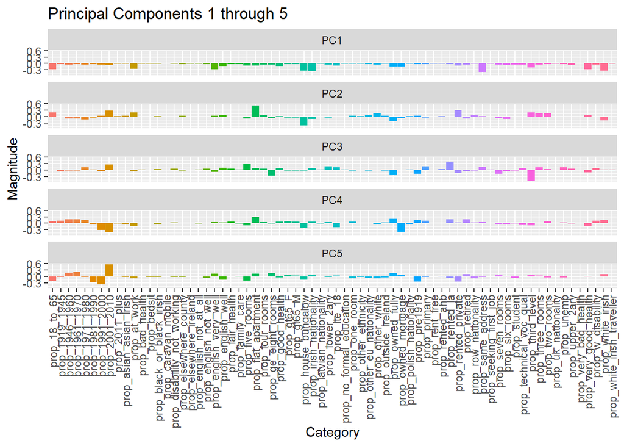

```r
tidied_pca <- tidy(pca_prep, 1)

tidied_pca %>%
  filter(component %in% paste0("PC", 1:5)) %>%
  mutate(component = fct_inorder(component)) %>%
  ggplot(aes(terms, value, fill = terms)) +
  geom_col(show.legend = FALSE) +
  facet_wrap(component~., ncol = 1) +
  labs(y = NULL) +
  theme(axis.text.x = element_text(angle = 90, vjust = 0.5, hjust=1)) +
  labs(title = "Principal Components 1 through 5",
       y = "Magnitude",
       x = "Category")
```

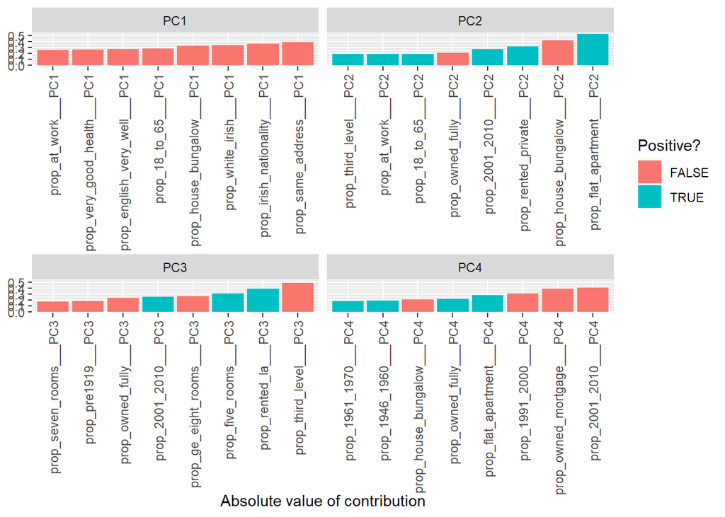

```r
library(tidytext)

tidied_pca %>%
  filter(component %in% paste0("PC", 1:4)) %>%
  group_by(component) %>%
  top_n(8, abs(value)) %>%
  ungroup() %>%
  mutate(terms = reorder_within(terms, abs(value), component)) %>%
  ggplot(aes(terms, abs(value), fill = value > 0)) +
  geom_col() +
  facet_wrap(component~., scales = "free_x") +
  theme(axis.text.x = element_text(angle = 90, vjust = 0.5, hjust=1)) +
  labs(
    x = "Absolute value of contribution",
    y = NULL, fill = "Positive?"
  )
```

The workflow outlined in Brunsdon et al’s [Ireland Census of Population 2011: A classification of Small Areas ERNIE - Echelons of Residential Neighbourhoods (IE)](https://rpubs.com/chrisbrunsdon/14998) will be utilised to develop clusters for Domestic Fire Risk in Dublin.

```r
PCA <- princomp(t0_cleaned[, -1], cor = T, scores = T)
PCA$sdev^2/sum(PCA$sdev^2)
```

```
##       Comp.1       Comp.2       Comp.3       Comp.4       Comp.5       Comp.6
## 2.501653e-01 1.220191e-01 8.878049e-02 4.230429e-02 3.707353e-02 3.082255e-02
##       Comp.7       Comp.8       Comp.9      Comp.10      Comp.11      Comp.12
## 2.595636e-02 2.311311e-02 2.289104e-02 1.989742e-02 1.882761e-02 1.685519e-02
##      Comp.13      Comp.14      Comp.15      Comp.16      Comp.17      Comp.18
## 1.593712e-02 1.438871e-02 1.354823e-02 1.324449e-02 1.290294e-02 1.221498e-02
##      Comp.19      Comp.20      Comp.21      Comp.22      Comp.23      Comp.24
## 1.206145e-02 1.103191e-02 1.090019e-02 1.068949e-02 1.025734e-02 9.431190e-03
##      Comp.25      Comp.26      Comp.27      Comp.28      Comp.29      Comp.30
## 9.229061e-03 8.667814e-03 8.442923e-03 7.849732e-03 7.608183e-03 7.513701e-03
##      Comp.31      Comp.32      Comp.33      Comp.34      Comp.35      Comp.36
## 7.011762e-03 6.898813e-03 6.400341e-03 6.128898e-03 5.904976e-03 5.674888e-03
##      Comp.37      Comp.38      Comp.39      Comp.40      Comp.41      Comp.42
## 5.503313e-03 5.286072e-03 4.732384e-03 4.634159e-03 4.399080e-03 4.215430e-03
##      Comp.43      Comp.44      Comp.45      Comp.46      Comp.47      Comp.48
## 3.767109e-03 3.362989e-03 3.275032e-03 3.015102e-03 2.899843e-03 2.806893e-03
##      Comp.49      Comp.50      Comp.51      Comp.52      Comp.53      Comp.54
## 2.708095e-03 2.461011e-03 2.368180e-03 1.932734e-03 1.848767e-03 1.703442e-03
##      Comp.55      Comp.56      Comp.57      Comp.58      Comp.59      Comp.60
## 1.607281e-03 1.263136e-03 1.132137e-03 5.904735e-04 5.177193e-04 4.009360e-04
##      Comp.61      Comp.62      Comp.63      Comp.64      Comp.65      Comp.66
## 3.113627e-04 2.115870e-04 1.834457e-04 7.321019e-05 6.577016e-05 3.030411e-05
##      Comp.67      Comp.68      Comp.69      Comp.70
## 2.841760e-05 1.949259e-05 2.819202e-17 1.946673e-17
```

```r
cumsum(PCA$sdev^2/sum(PCA$sdev^2))
```

```
##    Comp.1    Comp.2    Comp.3    Comp.4    Comp.5    Comp.6    Comp.7    Comp.8
## 0.2501653 0.3721844 0.4609649 0.5032691 0.5403427 0.5711652 0.5971216 0.6202347
##    Comp.9   Comp.10   Comp.11   Comp.12   Comp.13   Comp.14   Comp.15   Comp.16
## 0.6431257 0.6630232 0.6818508 0.6987060 0.7146431 0.7290318 0.7425800 0.7558245
##   Comp.17   Comp.18   Comp.19   Comp.20   Comp.21   Comp.22   Comp.23   Comp.24
## 0.7687275 0.7809424 0.7930039 0.8040358 0.8149360 0.8256255 0.8358828 0.8453140
##   Comp.25   Comp.26   Comp.27   Comp.28   Comp.29   Comp.30   Comp.31   Comp.32
## 0.8545431 0.8632109 0.8716538 0.8795035 0.8871117 0.8946254 0.9016372 0.9085360
##   Comp.33   Comp.34   Comp.35   Comp.36   Comp.37   Comp.38   Comp.39   Comp.40
## 0.9149363 0.9210652 0.9269702 0.9326451 0.9381484 0.9434345 0.9481669 0.9528010
##   Comp.41   Comp.42   Comp.43   Comp.44   Comp.45   Comp.46   Comp.47   Comp.48
## 0.9572001 0.9614155 0.9651826 0.9685456 0.9718207 0.9748358 0.9777356 0.9805425
##   Comp.49   Comp.50   Comp.51   Comp.52   Comp.53   Comp.54   Comp.55   Comp.56
## 0.9832506 0.9857116 0.9880798 0.9900125 0.9918613 0.9935647 0.9951720 0.9964351
##   Comp.57   Comp.58   Comp.59   Comp.60   Comp.61   Comp.62   Comp.63   Comp.64
## 0.9975673 0.9981578 0.9986755 0.9990764 0.9993878 0.9995994 0.9997828 0.9998560
##   Comp.65   Comp.66   Comp.67   Comp.68   Comp.69   Comp.70
## 0.9999218 0.9999521 0.9999805 1.0000000 1.0000000 1.0000000
```

```r
# set number of principal components
n.pc <- 20
```

Looking at the cumulative sums of the variance portion explained by each principal component, 80% of the variance is explained by the first 20 components. We will bring these forward into our clustering process.

```r
set.seed(290162)  # Reproducible outcome
then <- now()  # Time this - it takes a while

smallest.clus <- wss <- rep(0, 100)

for (i in 1:100) {
    clus <- kmeans(PCA$scores[, 1:n.pc], i, iter.max = 100, nstart = 20)
    wss[i] <- clus$tot.withinss
    smallest.clus[i] <- min(clus$size)
}

# How long did the calculation take?
elapsed <- now() - then

# Some diagnostic plots are required to set downstream parameters
plot(1:100, wss[1:100], type = "h", main = "Cluster Scree Plot", xlab = "Number of Clusters",
    ylab = "Within Cluster Sum of Squares")

plot(1:100, smallest.clus[1:100], type = "h", main = "Smallest Cluster Plot",
    xlab = "Number of Clusters", ylab = "Smallest Cluster Size")
```

[output not shown]

```r
# set seed to get the same answer each time!
set.seed(32767)

# set n.clus to the inflection point indicated above
n.clus <- 9

SAclus <- kmeans(PCA$scores[, 1:n.pc], n.clus, iter.max = 100, nstart = 20)

SAclusters <- SAclus$cluster

# We need this for the 'ddply' function
library(plyr)

# Compute a data frame (one row per cluster) containing the means of each
# variable in that cluster
mean_by_cluster <- ddply(t0_cleaned, .(SAclusters), numcolwise(mean))[, -1]

# Compute the column-wise means for *all* observations
mean_by_col <- apply(t0_cleaned[, -1], 2, mean)

# Compute the column-wise *sample* sd's for *all* observations
sd_by_col <- apply(t0_cleaned[, -1], 2, sd)

# Create the z-scores via the 'scale' function
z_scores <- scale(mean_by_cluster, center = mean_by_col, scale = sd_by_col)
```

A named cluster has been assigned to each of the Small Areas, based on the K-Means clustering algorithm on the variables prepared during Step 1. These have then in turn been transformed to explain each cluster in terms of the original variables, rather than the principal components.

The remaining step is to visualize the cluster breakdown.

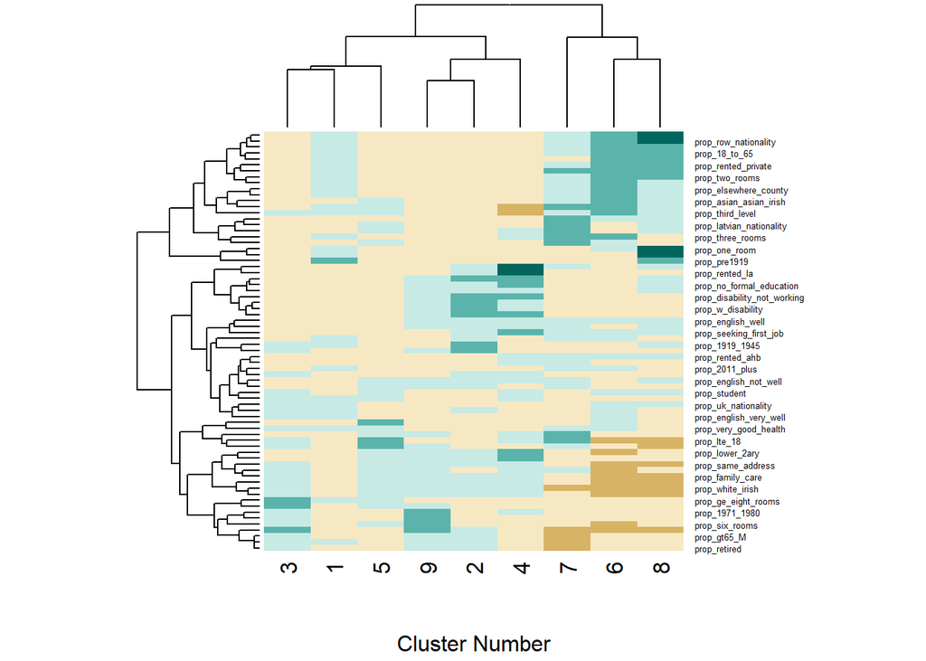

```r
library(RColorBrewer)
heatmap(t(z_scores),
        scale = 'none',
        col=brewer.pal(6,'BrBG'),
        breaks=c(-1e10,-2,-1,0,1,2,+1e10),
        xlab='Cluster Number',
        cexRow =0.5)
```

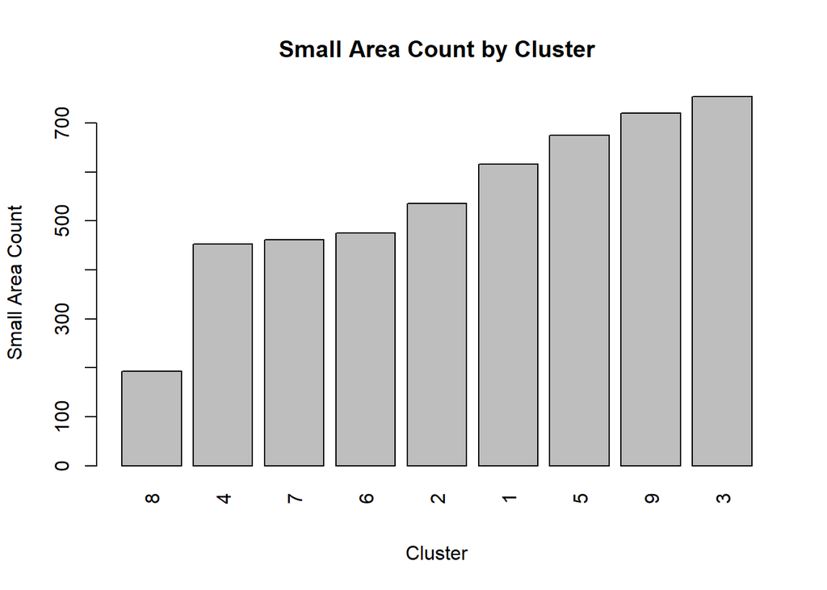

```r
barplot(sort(table(SAclusters)),
        las = 3,
        xlab = "Cluster",
        ylab = "Small Area Count",
        main = "Small Area Count by Cluster")
```